# R Módulo VI: Series de Tiempo

## Suavizamiento exponencial

Hay situaciones en donde las observaciones más recientes contienen información más actualizada sobre lo que se espera en el futuro y por lo tanto, se les tiene que dar un peso mayor que a las observaciones más antiguas. El método de suavizamiento exponencial calcula el pronóstico como una combinación entre el pronóstico del periodo anterior y la última observación disponible:
$$F_t(\alpha) = \alpha y_{t-1} + (1-\alpha)F_{t-1}$$
donde al parámetro $\alpha$ se le llama factor de suavizamiento, y $\alpha\in (0,1)$ es un peso que pondera la relación entre ambos términos.

```r
(se1 <- ses(ts.pasajeros, alpha= 0.3,h = 30))
```

```
         Point Forecast    Lo 80    Hi 80    Lo 95    Hi 95
Jan 1957         318.45 278.6634 358.2365 257.6017 379.2982
Feb 1957         318.45 276.9116 359.9883 254.9225 381.9774
Mar 1957         318.45 275.2307 361.6692 252.3518 384.5481
Apr 1957         318.45 273.6128 363.2871 249.8774 387.0225
May 1957         318.45 272.0513 364.8487 247.4893 389.4106
Jun 1957         318.45 270.5406 366.3593 245.1789 391.7210
Jul 1957         318.45 269.0761 367.8238 242.9392 393.9607
Aug 1957         318.45 267.6539 369.2460 240.7641 396.1358
Sep 1957         318.45 266.2704 370.6295 238.6482 398.2517
Oct 1957         318.45 264.9226 371.9773 236.5870 400.3130
Nov 1957         318.45 263.6080 373.2919 234.5764 402.3235
Dec 1957         318.45 262.3241 374.5758 232.6129 404.2870
Jan 1958         318.45 261.0690 375.8309 230.6933 406.2066
Feb 1958         318.45 259.8407 377.0592 228.8148 408.0851
Mar 1958         318.45 258.6376 378.2623 226.9749 409.9250
Apr 1958         318.45 257.4583 379.4416 225.1713 411.7286
May 1958         318.45 256.3014 380.5985 223.4019 413.4980
Jun 1958         318.45 255.1656 381.7343 221.6648 415.2351
Jul 1958         318.45 254.0498 382.8501 219.9584 416.9415
Aug 1958         318.45 252.9530 383.9469 218.2810 418.6189
Sep 1958         318.45 251.8743 385.0256 216.6313 420.2686
Oct 1958         318.45 250.8128 386.0871 215.0079 421.8920
Nov 1958         318.45 249.7677 387.1322 213.4095 423.4904
Dec 1958         318.45 248.7383 388.1616 211.8351 425.0648
Jan 1959         318.45 247.7238 389.1761 210.2837 426.6162
Feb 1959         318.45 246.7237 390.1762 208.7541 428.1458
Mar 1959         318.45 245.7374 391.1625 207.2457 429.6543
Apr 1959         318.45 244.7642 392.1357 205.7573 431.1426
May 1959         318.45 243.8038 393.0962 204.2884 432.6115
Jun 1959         318.45 242.8555 394.0444 202.8382 434.0617
```

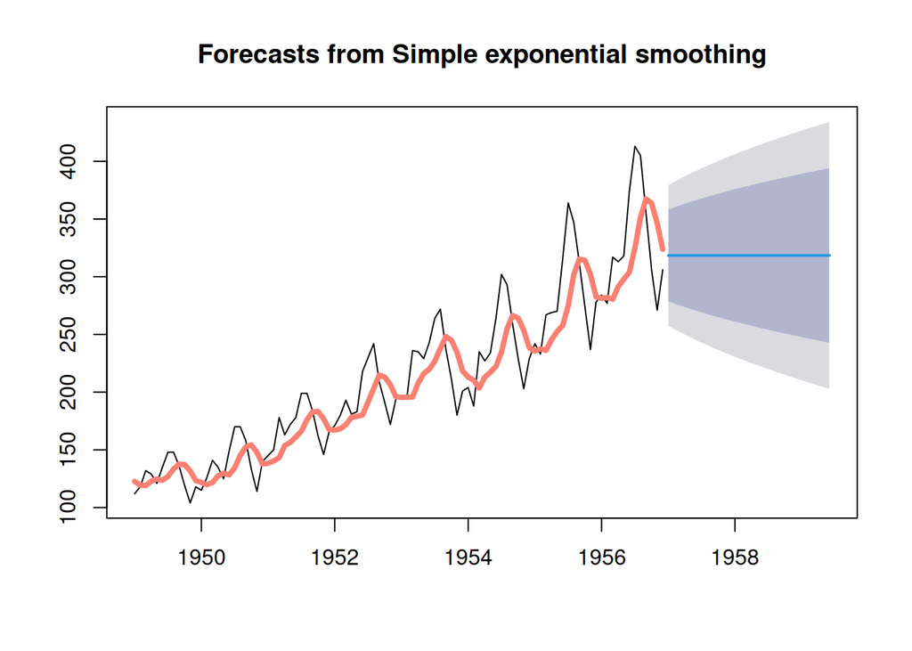

```r
plot(se1)
lines(se1$fitted,lwd=4,col="salmon")
```

```r
forecast(se1, h=20)
```

```
         Point Forecast    Lo 80    Hi 80    Lo 95    Hi 95
Jan 1957         318.45 278.6634 358.2365 257.6017 379.2982
Feb 1957         318.45 276.9116 359.9883 254.9225 381.9774
Mar 1957         318.45 275.2307 361.6692 252.3518 384.5481
Apr 1957         318.45 273.6128 363.2871 249.8774 387.0225
May 1957         318.45 272.0513 364.8487 247.4893 389.4106
Jun 1957         318.45 270.5406 366.3593 245.1789 391.7210
Jul 1957         318.45 269.0761 367.8238 242.9392 393.9607
Aug 1957         318.45 267.6539 369.2460 240.7641 396.1358
Sep 1957         318.45 266.2704 370.6295 238.6482 398.2517
Oct 1957         318.45 264.9226 371.9773 236.5870 400.3130
Nov 1957         318.45 263.6080 373.2919 234.5764 402.3235
Dec 1957         318.45 262.3241 374.5758 232.6129 404.2870
Jan 1958         318.45 261.0690 375.8309 230.6933 406.2066
Feb 1958         318.45 259.8407 377.0592 228.8148 408.0851
Mar 1958         318.45 258.6376 378.2623 226.9749 409.9250
Apr 1958         318.45 257.4583 379.4416 225.1713 411.7286
May 1958         318.45 256.3014 380.5985 223.4019 413.4980
Jun 1958         318.45 255.1656 381.7343 221.6648 415.2351
Jul 1958         318.45 254.0498 382.8501 219.9584 416.9415
Aug 1958         318.45 252.9530 383.9469 218.2810 418.6189
```

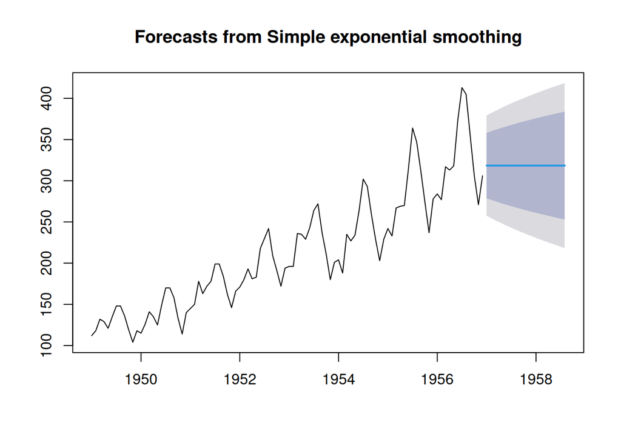

```r
plot(forecast(se1, h=20))
```

## Holt-Winters

Este es uno de los modelos más utilizados de pronósticos. El método de Holt-Winters está diseñado para datos estacionales. Winters (1960) extendió el método de Holt, y hay dos versiones dependiendo de cómo se modele la estacionalidad (aditiva o multiplicativa). En este caso se tienen 4 ecuaciones y 3 parámetros:

- Nivel $L_t = \alpha \frac{y_t}{S_{t-s}} + (1-\alpha)(L_{t-1}+b_{t-1})$
- Tendencia $b_t = \beta (L_t-L_{t-1}) + (1-\beta)b_{t-1}$
- Estacional $S_t = \gamma \frac{y_t}{L_t} + (1-\gamma)S_{t-s}$
- Pronóstico $F_{t+m} = (L_t+b_t m)S_{t-s+m}$

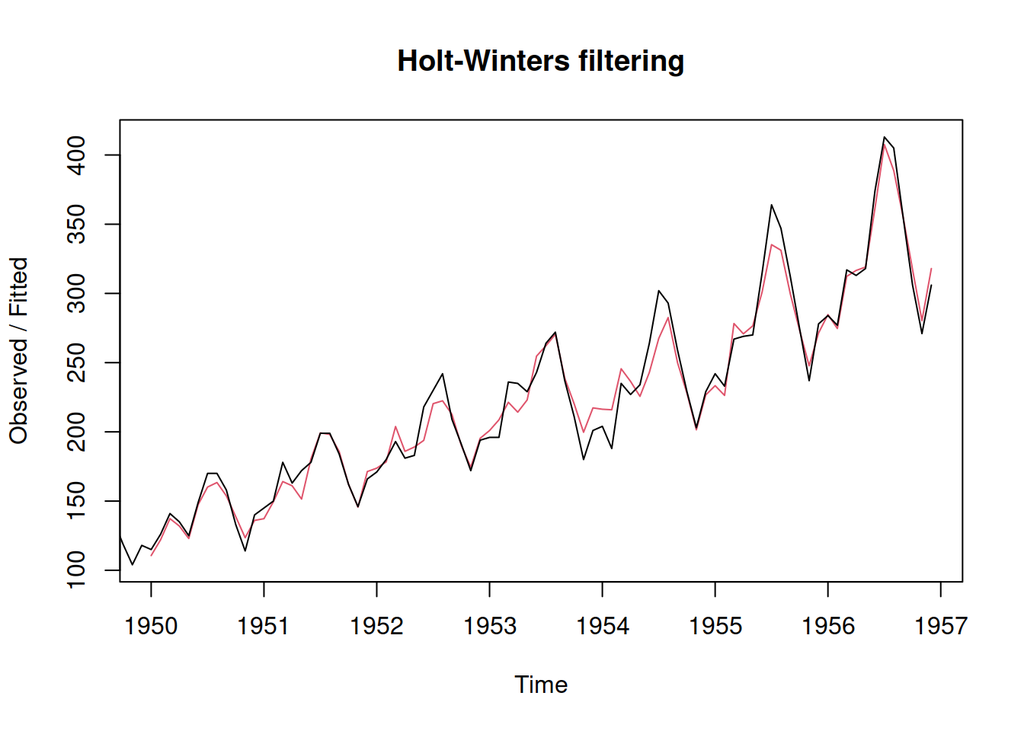

```r
m <- HoltWinters(ts.pasajeros)
plot(m) # la serie completa
```

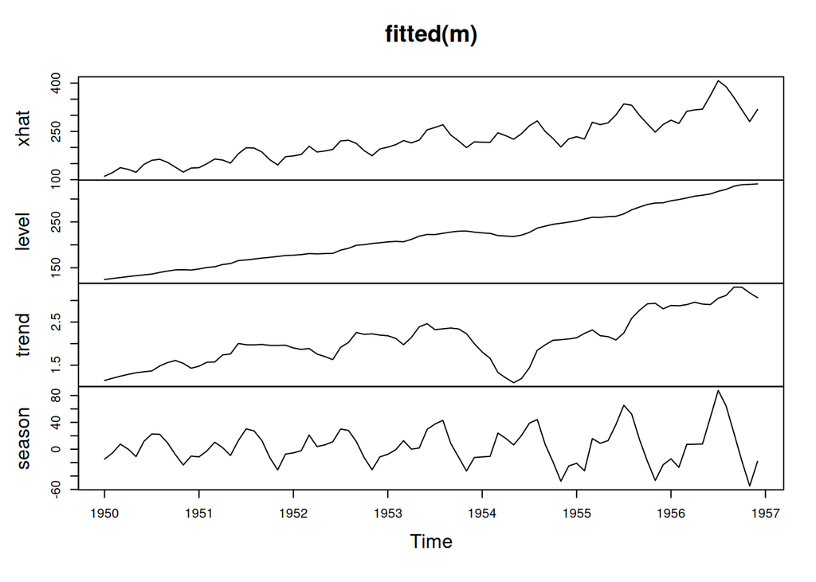

```r
plot(fitted(m)) # los componentes de la serie estimada
```

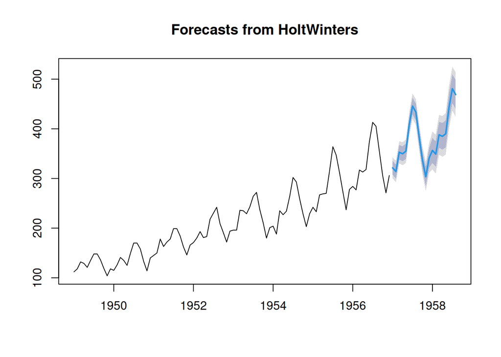

```r
plot(forecast(m, h = 20))
```

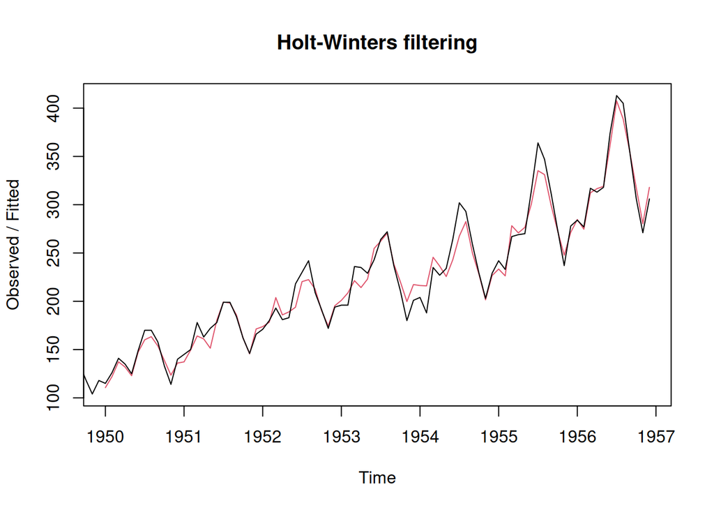

```r
# se puede tener control fino de cada parámetro
plot(HoltWinters(ts.pasajeros, seasonal = "additive"))
```

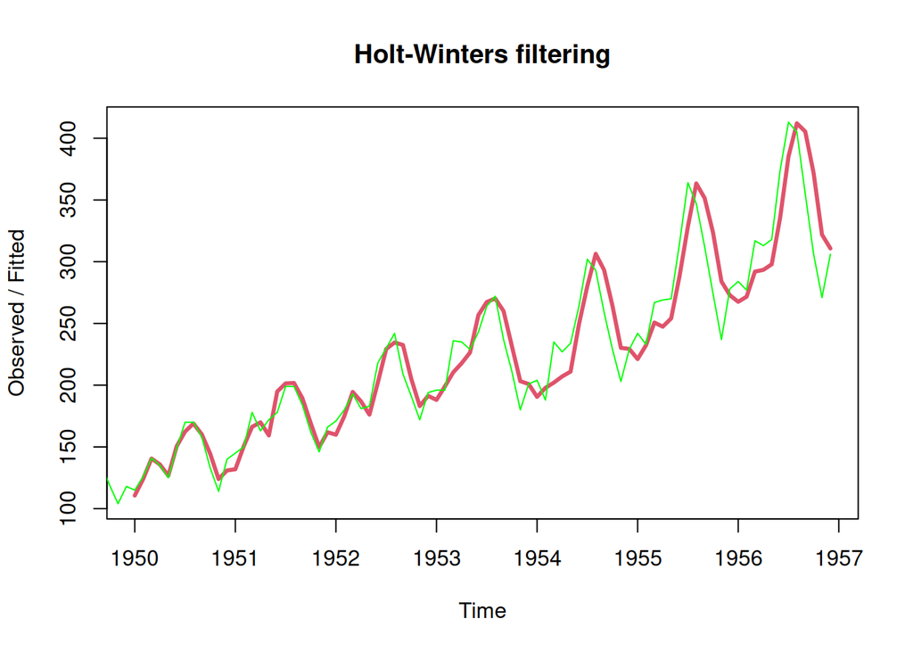

```r
plot(HoltWinters(ts.pasajeros, alpha = 0.5, beta = 0.4, gamma = 0.2), col = "green", lwd = 3)
```

## Box y Jenkins

Aquí agrego un resumen de las herramientas que son necesarias para hacer un análisis de series de tiempo tipo Box-Jenkins. Algunas son necesarias para construir el modelo y otras son necesarias para diagnosticar el modelo.

En lo que sigue, se dará un repaso muy general de estos conceptos, y veremos varios ejemplos para ir aplicando los conceptos.

### Ejemplo

Para conocer el margen de mercado que tiene Kimberly-Clark con la marca kleenex, se le han pedido su producción semanal, que reporta para las 120 semanas anteriores a esta y en unidades de 10,000 paquetes. Se requiere un modelo para analizar su comportamiento y hacer un pronóstico para saber si no está inundando el mercado.

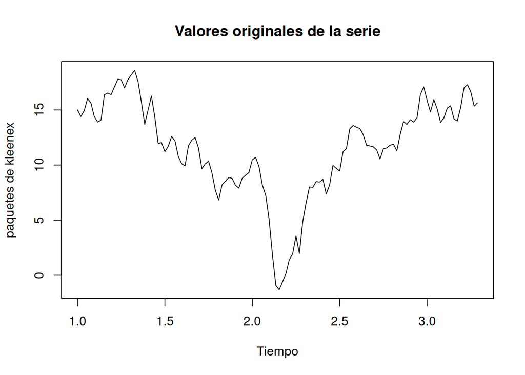

```r
kleenex <- read.table("kleenex.txt")   # lee los datos
kleenex <- ts(kleenex, start = 1, freq = 52)  # convierte a una serie con frecuencia semanal.
plot(kleenex, main = "Valores originales de la serie",
              xlab = "Tiempo",
              ylab = "paquetes de kleenex")
```

Vemos que la serie no parece fluctuar en torno a una media constante, y por lo tanto no parece ser estacionaria. Si tomamos las primeras diferencias de la serie, definidas como $z_t = y_t - y_{t-1}$ utilizando el operador `diff` obtenemos lo siguiente:

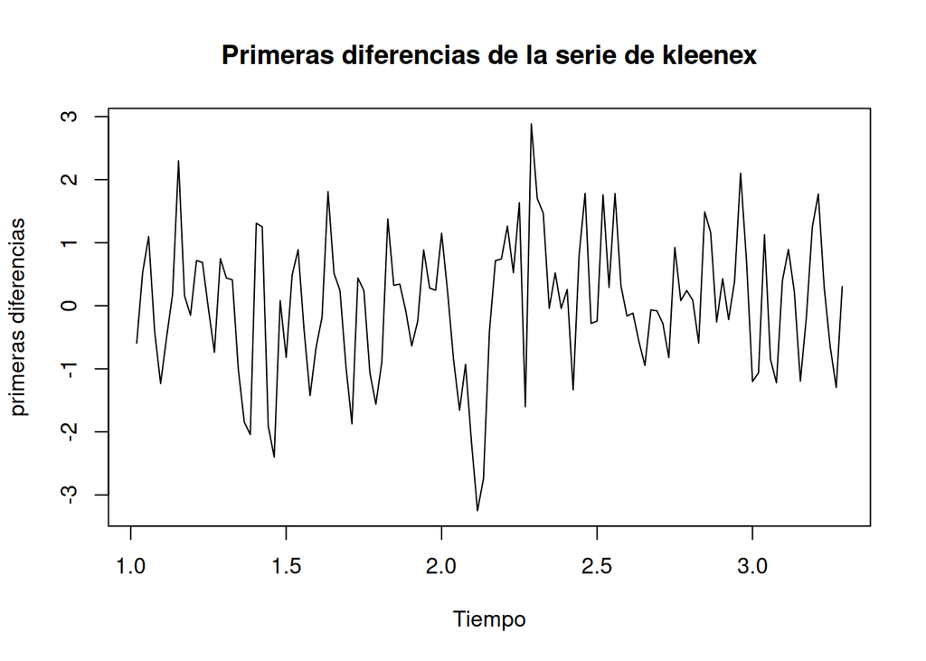

```r
dkleenex <- diff(kleenex, differences = 1)
plot(dkleenex, main = "Primeras diferencias de la serie de kleenex",
               xlab = "Tiempo",
               ylab = "primeras diferencias")
```

Ahora la serie parece fluctuar alrededor de una media constante, por lo que la primera diferencia parece ser estacionaria.

En ocasiones no es suficiente tomar sólo una diferencia. Si la primera diferencia no resulta estacionaria, entonces debemos tomar una segunda diferencia. Por ejemplo, tomamos la segunda diferencia de estos datos:

```r
d2kleenex <- diff(kleenex, difference = 2)
head(d2kleenex)
```

```
Time Series:
Start = c(1, 3)
End = c(1, 8)
Frequency = 52
          V1
[1,]  1.1255
[2,]  0.5672
[3,] -1.5045
[4,] -0.8291
[5,]  0.7329
[6,]  0.6822
```

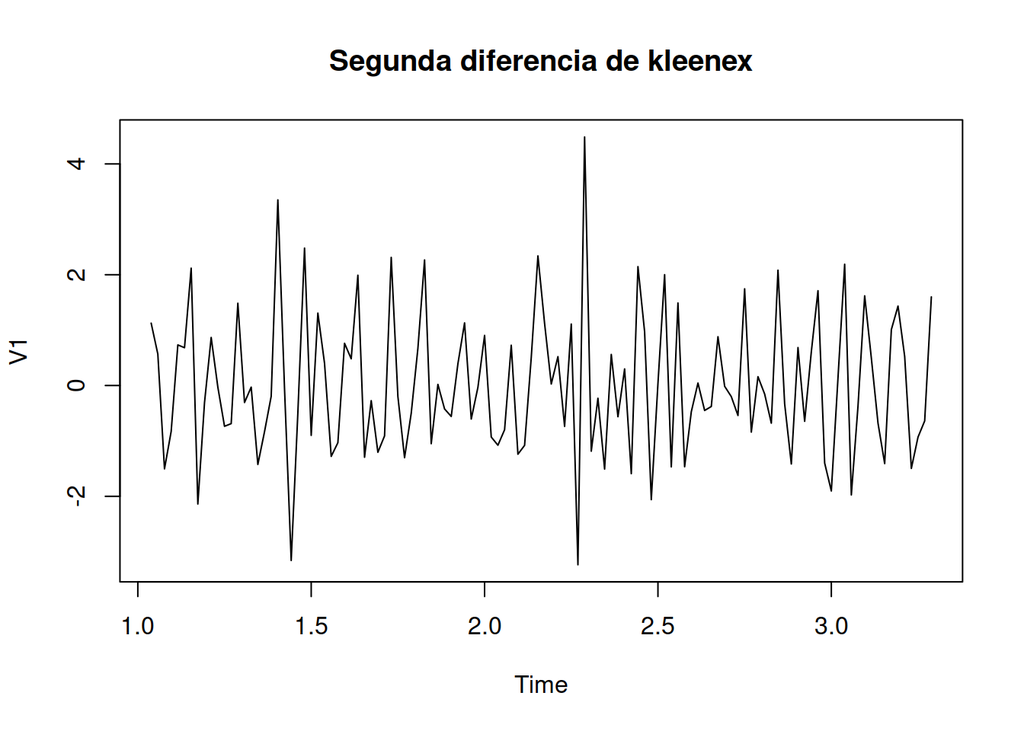

```r
plot(d2kleenex, main = "Segunda diferencia de kleenex")
```

Identificando estacionariedad con las funciones de autocorrelación:

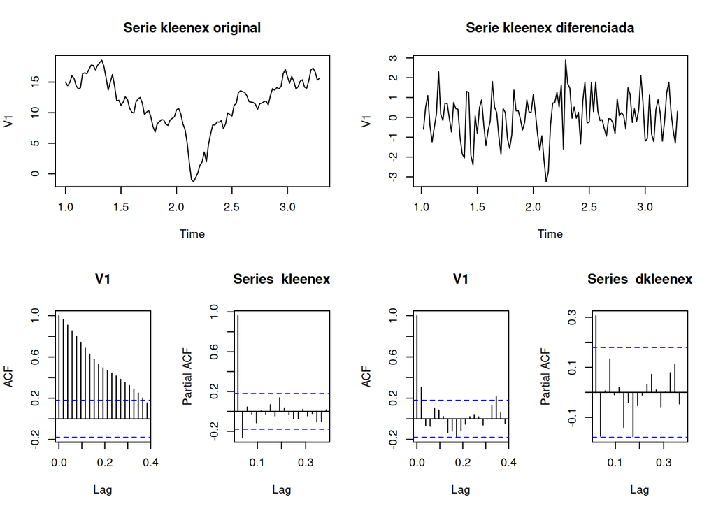

```r
layout(matrix(c(1,1,2,2,3,4,5,6),nrow=2,byrow=T))
plot(kleenex, main = "Serie kleenex original")
plot(dkleenex, main = "Serie kleenex diferenciada")
acf(kleenex)
pacf(kleenex)
acf(dkleenex)
pacf(dkleenex)
```

Pruebas de Box (Box-Pierce y Ljung-Box):

```r
Box.test(dkleenex, lag = 1, type = "Box") # h= 1 en este ejemplo
```

```
    Box-Pierce test

data:  dkleenex
X-squared = 11.189, df = 1, p-value = 0.000823
```

```r
Box.test(dkleenex, lag = 1, type = "Ljung")
```

```
    Box-Ljung test

data:  dkleenex
X-squared = 11.473, df = 1, p-value = 0.0007061
```

Cálculo de modelos ARIMA por fuerza bruta:

```r
#AIC guarda el criterio de información de Akaike
AIC <- array(NA, dim=c(4,2,4), dimnames = list(paste("p=",0:3), paste("d=",0:1), paste("q=",0:3)))
for(p in 1:4) for(q in 1:4) for(d in 1:2) AIC[p,d,q] <- arima(kleenex, order = c(p-1,d-1,q-1))$aic
AIC
```

```
, , q= 0

         d= 0     d= 1
p= 0 698.9005 362.2711
p= 1 369.6550 352.5789
p= 2 358.3822 350.7612
p= 3 357.5850 352.7582

, , q= 1

         d= 0     d= 1
p= 0 568.3708 349.9821
p= 1 356.3556 351.9658
p= 2 358.2153 352.7601
p= 3 359.5559 352.4818

, , q= 2

         d= 0     d= 1
p= 0 475.5712 351.9519
p= 1 358.1165 351.3134
p= 2 357.4390 353.5758
p= 3 359.2680 349.9126

, , q= 3

         d= 0     d= 1
p= 0 437.5709 351.8757
p= 1 358.6551 352.6993
p= 2 359.2192 353.2524
p= 3 360.9870 350.9945
```

Elegimos dos modelos relativamente cercanos, para ver los coeficientes

```r
mod1 <- arima(kleenex,order = c(3,1,2))
mod1
```

```
Call:
arima(x = kleenex, order = c(3, 1, 2))

Coefficients:
         ar1      ar2     ar3      ma1     ma2
      1.5308  -1.3686  0.3847  -1.2517  0.9587
s.e.  0.0876   0.1047  0.0894   0.0463  0.0711

sigma^2 estimated as 0.9869:  log likelihood = -168.96,  aic = 349.91
```

```r
mod2 <- arima(kleenex, order = c(0,1,1))
mod2
```

```
Call:
arima(x = kleenex, order = c(0, 1, 1))

Coefficients:
         ma1
      0.3518
s.e.  0.0800

sigma^2 estimated as 1.071:  log likelihood = -172.99,  aic = 349.98
```